# Estudio de la popularidad de la universidad del valle frente al paro estudiantil ocurrido entre octubre y diciembre del 2018 mediante el uso del análisis de sentimientos - Código fuente

Victor Duvan Ruiz Ochoa

*2021*

Librerías utilizadas.

```r
library(tm)
library(stringi)
library(stringr)
library(dplyr)
library(naivebayes)
library(e1071)
library(caret)
library(C50)
library(class)
library(rpart)
library(neuralnet)
library(DMwR)
library(MLmetrics)
library(quanteda)
library(ggplot2)
```

Se importan los datos obtenidos con las herramienta de web scraping del autor Jefferson Henrique disponible [en este enlace](https://github.com/Jefferson-Henrique/GetOldTweets-python). También se ordena el data frame y se filtran las cuentas que se establecieron.

```r
univalle <- read.csv("univalle.csv", sep = ";", quote = "", encoding = "UTF-8")
u <- univalle[!grepl("#",univalle$id) & !grepl("@",univalle$id) & univalle$id != "",]

udv <- read.csv("universidad_del_valle.csv", sep = ";", quote = "", encoding = "UTF-8")
u2 <- udv[!grepl("#",udv$id) & !grepl("@",udv$id) & udv$id != "",]


datos.raw <- rbind(u,u2)

datos.raw <- datos.raw[!duplicated(datos.raw$id), ]
datos.raw <- datos.raw[!duplicated(datos.raw$text), ]

datos.raw <- datos.raw[!(datos.raw$username %in% c("XIXCAMUV", "UnivalleCol", "Univalle_FSalud", "Univalle_Nic",
                               "univallebolivia", "UnivalleBun", "univalle_pln")),]

datos.raw$id <- str_replace_all(datos.raw$id, "[^[:alnum:]]", "")
```

Se extrae la muestra con 900 publicaciones para la clasificación en la aplicación externa.

```r
to_app <- sample_n(datos.raw, size= 900)
to_app <- to_app[,c("id","username","text")]
to_app$sentiment <- rep("",length(to_app$id))
write.csv(to_app,file="datos.csv",row.names = FALSE)
```

Se importan el resultado de la clasificación de los datos.

```r
datos.clasificados <- read.csv("datos_clasificados.csv")
```

Se realiza el proceso de tokenizacióny se crea una función para ello.

```r
limpiar <- function(texs){
  tokens <- gsub("[[:cntrl:]]", " ", texs)
  tokens <- tolower(tokens)
  tokens <- removeWords(tokens, words = c(stopwords("spanish"),"www","http","https","com"))
  tokens <- str_replace_all(tokens, "[^[:alnum:]]", " ")
  tokens <- removePunctuation(tokens)
  tokens <- removeNumbers(tokens)
  tokens <- stripWhitespace(tokens)
  tokens <- stri_trans_general(tokens,"Latin-ASCII")
  tokens
}
tokens <- limpiar(datos.clasificados$text)
```

Se realiza el proceso de TF-IDF.

```r
doc.dfm <- dfm(x = tokens)
doc.dfm <- dfm_select(doc.dfm, min_nchar = 3, max_nchar = 15)
doc.matriz.tfidf <- dfm_trim(x = doc.dfm, min_docfreq = 7)
doc.matriz.tfidf <- dfm_tfidf(doc.matriz.tfidf, scheme_tf = "prop", scheme_df = "inverse")
datos.matriz.tfidf <- data.frame(sentiment=datos.clasificados$sentiment,
                                 convert(doc.matriz.tfidf, to="data.frame")[,-1])
datos.matriz.tfidf$sentiment <- as.factor(datos.matriz.tfidf$sentiment)
```

Se crea un diccionario con los parámetros de entrada de los modelos para los datos futuros.

```r
dimensiones.matriz.tfidf <- doc.matriz.tfidf@Dimnames$features
dimensiones.matriz.tfidf <- as.list(dimensiones.matriz.tfidf)
names(dimensiones.matriz.tfidf) <- unlist(dimensiones.matriz.tfidf)
dimensiones.matriz.tfidf <- dictionary(dimensiones.matriz.tfidf)
```

## Analisis exploratorio de los datos

Se crea los graficos del número de publicaciones hechas a través del tiempo.

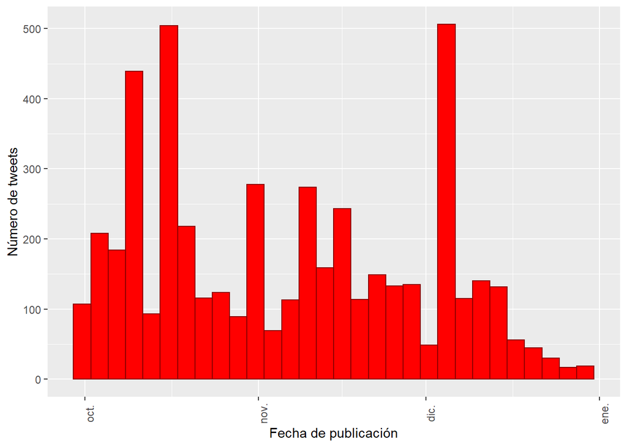

```r
#pdf(file = "numero_de_tweets_publicados.pdf",height = 5, width = 10)  # abrir el device, en este caso pdf

ggplot(datos.raw, aes(x = as.Date(date))) +
  geom_histogram(colour = "#8B0000",fill="#FF0000")+
  labs(x = "Fecha de publicación", y = "Número de tweets") +
  theme(axis.text.x = element_text(angle = 90))
```

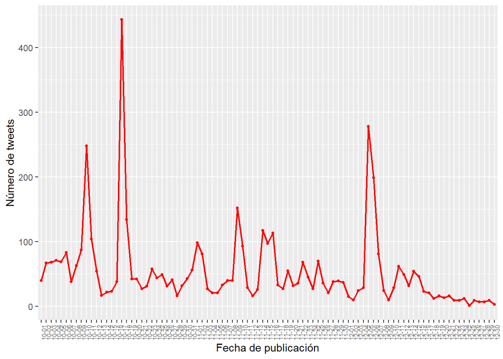

```r
#dev.off()


#pdf(file = "numero_de_tweets_publicados_2.pdf",height = 5, width = 10)
tweets_mes_anyo <- datos.raw %>% mutate(mes_anyo = format(as.Date(date), "%m-%d"))
tweets_mes_anyo %>% group_by(mes_anyo) %>% summarise(n = n())%>%
  ggplot(aes(x = mes_anyo, y = n)) +
  geom_line(aes(group=1),size=0.8,color="red") +
  geom_point(aes(group=1),size=1,color="red")+
  labs( x = "Fecha de publicación",
       y = "Número de tweets") +
  theme(axis.text.x = element_text(angle = 90, size = 6))
```

```r
#dev.off()
```

Se crea el grafico de las palabras mas usadas por los usuarios.

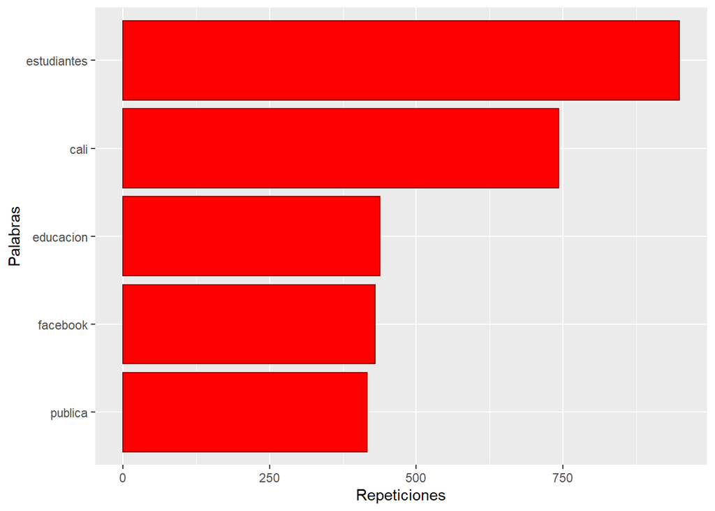

```r
tokens.all <- limpiar(datos.raw$text)

frecuencia <- dfm_select(dfm(x = tokens.all),min_nchar = 3, max_nchar=15)[,-1] %>%
  colSums() %>% sort(decreasing = TRUE)
frecuencia <- data.frame(palabra = names(frecuencia), frec = frecuencia)
row.names(frecuencia) <- 1:length(frecuencia$frec)

#pdf(file = "palabras_mas_usadas.pdf",height = 5, width = 10)
ggplot(data=frecuencia[4:8,], aes(y = frec,x = reorder(palabra,frec))) +
  geom_bar(stat="identity",colour = "#8B0000",fill="#FF0000") +
  coord_flip()+
  labs( x = "Palabras",
       y = "Repeticiones")
```

```r
#dev.off()
```

Se crea el grafico de los usuarios con mas publicaciones.

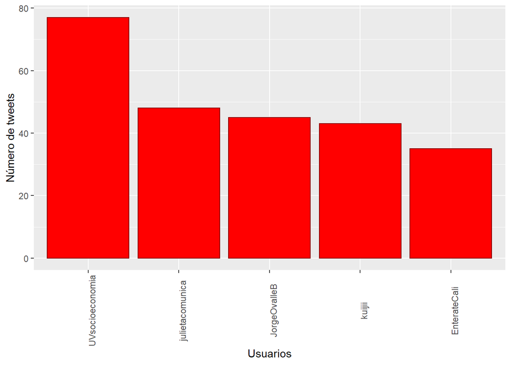

```r
frecuencia_users <- table(datos.raw$username)%>% sort(decreasing = TRUE)
frecuencia_users <- data.frame(user = names(frecuencia_users), frecuencia_users)

#pdf(file = "usuarios_mas_publicaciones.pdf",height = 5, width = 10)
ggplot(frecuencia_users[1:5,], aes(x = reorder(user, -Freq), y=Freq)) +
  geom_histogram(stat="identity",colour = "#8B0000",fill="#FF0000")+
  labs(x = "Usuarios", y = "Número de tweets") +
  theme(axis.text.x = element_text(angle = 90))
```

```r
#dev.off()
```

## Entrenamiento de los modelos de clasificación

Se separa los datos en 70% para entrenamiento y 30% para pruebas.

```r
set.seed(45)
ind <- sample(2,nrow(datos.matriz.tfidf), replace = TRUE, prob = c(0.7,0.3) ) #70% entrenamiento y 30% test
trainData<- datos.matriz.tfidf[ind==1,]
testData<- datos.matriz.tfidf[ind==2,]
```

### Entrenamiento y evaluación sin técnicas de balanceo de datos

Entrenamiento y evaluación del modelo SVM.

```r
svm <- svm(sentiment~., data=trainData, kernel='sigmoid')
prediction.svm <- predict(svm, newdata = testData[,-1])

confusionMatrix(table(testData[,1],prediction.svm))
```

```
## Confusion Matrix and Statistics
##
##     prediction.svm
##       -1   0   1
##   -1  10  30   0
##   0    8 173   2
##   1    3  21   2
##
## Overall Statistics
##
##                Accuracy : 0.743
##                  95% CI : (0.684, 0.7961)
##     No Information Rate : 0.8996
##     P-Value [Acc > NIR] : 1
##
##                   Kappa : 0.2058
##
##  Mcnemar's Test P-Value : 6.892e-07
##
## Statistics by Class:
##
##                      Class: -1 Class: 0 Class: 1
## Sensitivity            0.47619   0.7723 0.500000
## Specificity            0.86842   0.6000 0.902041
## Pos Pred Value         0.25000   0.9454 0.076923
## Neg Pred Value         0.94737   0.2273 0.991031
## Prevalence             0.08434   0.8996 0.016064
## Detection Rate         0.04016   0.6948 0.008032
## Detection Prevalence   0.16064   0.7349 0.104418
## Balanced Accuracy      0.67231   0.6862 0.701020
```

```r
F1_Score(testData$sentiment, prediction.svm,"-1")
```

```
## [1] 0.3278689
```

```r
F1_Score(testData$sentiment, prediction.svm,"0")
```

```
## [1] 0.8501229
```

```r
F1_Score(testData$sentiment, prediction.svm,"1")
```

```
## [1] 0.1333333
```

```r
Recall(testData$sentiment, prediction.svm,"-1")
```

```
## [1] 0.25
```

```r
Recall(testData$sentiment, prediction.svm,"0")
```

```
## [1] 0.9453552
```

```r
Recall(testData$sentiment, prediction.svm,"1")
```

```
## [1] 0.07692308
```

```r
Precision(testData$sentiment, prediction.svm,"-1")
```

```
## [1] 0.4761905
```

```r
Precision(testData$sentiment, prediction.svm,"0")
```

```
## [1] 0.7723214
```

```r
Precision(testData$sentiment, prediction.svm,"1")
```

```
## [1] 0.5
```

Entrenamiento y evaluación del modelo árbol de decisión.

```r
arbol <- rpart(sentiment ~ ., data = trainData)
prediccion.arbol <- predict(arbol, newdata = testData, type = "class")

confusionMatrix(prediccion.arbol, testData$sentiment)
```

```
## Confusion Matrix and Statistics
##
##           Reference
## Prediction  -1   0   1
##         -1  11   8   1
##         0   28 160  22
##         1    1  15   3
##
## Overall Statistics
##
##                Accuracy : 0.6988
##                  95% CI : (0.6377, 0.7551)
##     No Information Rate : 0.7349
##     P-Value [Acc > NIR] : 0.912342
##
##                   Kappa : 0.1617
##
##  Mcnemar's Test P-Value : 0.006031
##
## Statistics by Class:
##
##                      Class: -1 Class: 0 Class: 1
## Sensitivity            0.27500   0.8743  0.11538
## Specificity            0.95694   0.2424  0.92825
## Pos Pred Value         0.55000   0.7619  0.15789
## Neg Pred Value         0.87336   0.4103  0.90000
## Prevalence             0.16064   0.7349  0.10442
## Detection Rate         0.04418   0.6426  0.01205
## Detection Prevalence   0.08032   0.8434  0.07631
## Balanced Accuracy      0.61597   0.5584  0.52182
```

```r
F1_Score(testData$sentiment, prediccion.arbol,"-1")
```

```
## [1] 0.3666667
```

```r
F1_Score(testData$sentiment, prediccion.arbol,"0")
```

```
## [1] 0.8142494
```

```r
F1_Score(testData$sentiment, prediccion.arbol,"1")
```

```
## [1] 0.1333333
```

```r
Recall(testData$sentiment, prediccion.arbol,"-1")
```

```
## [1] 0.275
```

```r
Recall(testData$sentiment, prediccion.arbol,"0")
```

```
## [1] 0.8743169
```

```r
Recall(testData$sentiment, prediccion.arbol,"1")
```

```
## [1] 0.1153846
```

```r
Precision(testData$sentiment, prediccion.arbol,"-1")
```

```
## [1] 0.55
```

```r
Precision(testData$sentiment, prediccion.arbol,"0")
```

```
## [1] 0.7619048
```

```r
Precision(testData$sentiment, prediccion.arbol,"1")
```

```
## [1] 0.1578947
```

Entrenamiento y evaluación del modelo KNN.

```r
knn_3 <- knn(train =trainData[,-1],test =testData[,-1],cl=trainData$sentiment,k=3)

confusionMatrix(table(testData$sentiment,knn_3))
```

```
## Confusion Matrix and Statistics
##
##     knn_3
##       -1   0   1
##   -1   4  36   0
##   0    7 170   6
##   1    0  23   3
##
## Overall Statistics
##
##                Accuracy : 0.7108
##                  95% CI : (0.6502, 0.7663)
##     No Information Rate : 0.9197
##     P-Value [Acc > NIR] : 1
##
##                   Kappa : 0.0768
##
##  Mcnemar's Test P-Value : NA
##
## Statistics by Class:
##
##                      Class: -1 Class: 0 Class: 1
## Sensitivity            0.36364   0.7424  0.33333
## Specificity            0.84874   0.3500  0.90417
## Pos Pred Value         0.10000   0.9290  0.11538
## Neg Pred Value         0.96651   0.1061  0.97309
## Prevalence             0.04418   0.9197  0.03614
## Detection Rate         0.01606   0.6827  0.01205
## Detection Prevalence   0.16064   0.7349  0.10442
## Balanced Accuracy      0.60619   0.5462  0.61875
```

```r
F1_Score(testData$sentiment, knn_3,"-1")
```

```
## [1] 0.1568627
```

```r
F1_Score(testData$sentiment, knn_3,"0")
```

```
## [1] 0.8252427
```

```r
F1_Score(testData$sentiment, knn_3,"1")
```

```
## [1] 0.1714286
```

```r
Recall(testData$sentiment, knn_3,"-1")
```

```
## [1] 0.1
```

```r
Recall(testData$sentiment, knn_3,"0")
```

```
## [1] 0.9289617
```

```r
Recall(testData$sentiment, knn_3,"1")
```

```
## [1] 0.1153846
```

```r
Precision(testData$sentiment, knn_3,"-1")
```

```
## [1] 0.3636364
```

```r
Precision(testData$sentiment, knn_3,"0")
```

```
## [1] 0.7423581
```

```r
Precision(testData$sentiment, knn_3,"1")
```

```
## [1] 0.3333333
```

Entrenamiento y evaluación de la red neuronal.

```r
trainDataNet <- trainData
trainDataNet$sentiment <- as.numeric(trainDataNet$sentiment) - 1
testDataNet <- testData
testDataNet$sentiment <- as.numeric(testDataNet$sentiment) - 1

neur <- neuralnet(sentiment ~ ., data=trainDataNet, hidden=c(150,40,20), threshold=0.01)
neur.pred <- compute(neur, testDataNet[,-1])

net.result <- data.frame(actual=testDataNet[,1], pred=neur.pred$net.result)
net.result <- data.frame(sapply(net.result, round, digits=0))

pred.fix <- ifelse(net.result$pred<0, 0, net.result$pred)
pred.fix <- ifelse(pred.fix>2, 2, pred.fix)

confusionMatrix(table(net.result$actual,pred.fix))
```

```
## Confusion Matrix and Statistics
##
##    pred.fix
##       0   1   2
##   0   9  29   2
##   1  24 139  20
##   2   4  14   8
##
## Overall Statistics
##
##                Accuracy : 0.6265
##                  95% CI : (0.5632, 0.6868)
##     No Information Rate : 0.7309
##     P-Value [Acc > NIR] : 0.9999
##
##                   Kappa : 0.124
##
##  Mcnemar's Test P-Value : 0.5325
##
## Statistics by Class:
##
##                      Class: 0 Class: 1 Class: 2
## Sensitivity           0.24324   0.7637  0.26667
## Specificity           0.85377   0.3433  0.91781
## Pos Pred Value        0.22500   0.7596  0.30769
## Neg Pred Value        0.86603   0.3485  0.90135
## Prevalence            0.14859   0.7309  0.12048
## Detection Rate        0.03614   0.5582  0.03213
## Detection Prevalence  0.16064   0.7349  0.10442
## Balanced Accuracy     0.54851   0.5535  0.59224
```

```r
F1_Score(net.result$actual, pred.fix,"0")
```

```
## [1] 0.2337662
```

```r
F1_Score(net.result$actual, pred.fix,"1")
```

```
## [1] 0.7616438
```

```r
F1_Score(net.result$actual, pred.fix,"2")
```

```
## [1] 0.2857143
```

```r
Recall(net.result$actual, pred.fix,"0")
```

```
## [1] 0.225
```

```r
Recall(net.result$actual, pred.fix,"1")
```

```
## [1] 0.7595628
```

```r
Recall(net.result$actual, pred.fix,"2")
```

```
## [1] 0.3076923
```

```r
Precision(net.result$actual, pred.fix,"0")
```

```
## [1] 0.2432432
```

```r
Precision(net.result$actual, pred.fix,"1")
```

```
## [1] 0.7637363
```

```r
Precision(net.result$actual, pred.fix,"2")
```

```
## [1] 0.2666667
```

### Entrenamiento y evaluación con la técnica downsampling

Se aplica esta técnica a los datos de entrenamiento y prueba.

```r
downSampled.train = downSample(trainData[, -1], as.factor(trainData$sentiment))
downSampled.test = downSample(testData[, -1], as.factor(testData$sentiment))
```

Entrenamiento y evaluación del modelo SVM.

```r
svm.down <- svm(Class~., data=downSampled.train, kernel='sigmoid')
prediction.downsvm <- predict(svm.down, newdata = downSampled.test[,-(dim(downSampled.test)[2])])

confusionMatrix(table(downSampled.test$Class,prediction.downsvm))
```

```
## Confusion Matrix and Statistics
##
##     prediction.downsvm
##      -1  0  1
##   -1 11 13  2
##   0   2 22  2
##   1   3 17  6
##
## Overall Statistics
##
##                Accuracy : 0.5
##                  95% CI : (0.3846, 0.6154)
##     No Information Rate : 0.6667
##     P-Value [Acc > NIR] : 0.9991976
##
##                   Kappa : 0.25
##
##  Mcnemar's Test P-Value : 0.0001612
##
## Statistics by Class:
##
##                      Class: -1 Class: 0 Class: 1
## Sensitivity             0.6875   0.4231  0.60000
## Specificity             0.7581   0.8462  0.70588
## Pos Pred Value          0.4231   0.8462  0.23077
## Neg Pred Value          0.9038   0.4231  0.92308
## Prevalence              0.2051   0.6667  0.12821
## Detection Rate          0.1410   0.2821  0.07692
## Detection Prevalence    0.3333   0.3333  0.33333
## Balanced Accuracy       0.7228   0.6346  0.65294
```

```r
F1_Score(downSampled.test$Class, prediction.downsvm,"-1")
```

```
## [1] 0.5238095
```

```r
F1_Score(downSampled.test$Class, prediction.downsvm,"0")
```

```
## [1] 0.5641026
```

```r
F1_Score(downSampled.test$Class, prediction.downsvm,"1")
```

```
## [1] 0.3333333
```

```r
Recall(downSampled.test$Class, prediction.downsvm,"-1")
```

```
## [1] 0.4230769
```

```r
Recall(downSampled.test$Class, prediction.downsvm,"0")
```

```
## [1] 0.8461538
```

```r
Recall(downSampled.test$Class, prediction.downsvm,"1")
```

```
## [1] 0.2307692
```

```r
Precision(downSampled.test$Class, prediction.downsvm,"-1")
```

```
## [1] 0.6875
```

```r
Precision(downSampled.test$Class, prediction.downsvm,"0")
```

```
## [1] 0.4230769
```

```r
Precision(downSampled.test$Class, prediction.downsvm,"1")
```

```
## [1] 0.6
```

Entrenamiento y evaluación del modelo árbol de decisión.

```r
arbol.down <- rpart(Class ~ ., data = downSampled.train)
prediccion.down.arbol <- predict(arbol.down, newdata = downSampled.test[,-(dim(downSampled.test)[2])], type = "class")
confusionMatrix(table(downSampled.test$Class,prediccion.down.arbol ))
```

```
## Confusion Matrix and Statistics
##
##     prediccion.down.arbol
##      -1  0  1
##   -1 12 11  3
##   0   4 19  3
##   1   2 18  6
##
## Overall Statistics
##
##                Accuracy : 0.4744
##                  95% CI : (0.3601, 0.5907)
##     No Information Rate : 0.6154
##     P-Value [Acc > NIR] : 0.995858
##
##                   Kappa : 0.2115
##
##  Mcnemar's Test P-Value : 0.002669
##
## Statistics by Class:
##
##                      Class: -1 Class: 0 Class: 1
## Sensitivity             0.6667   0.3958  0.50000
## Specificity             0.7667   0.7667  0.69697
## Pos Pred Value          0.4615   0.7308  0.23077
## Neg Pred Value          0.8846   0.4423  0.88462
## Prevalence              0.2308   0.6154  0.15385
## Detection Rate          0.1538   0.2436  0.07692
## Detection Prevalence    0.3333   0.3333  0.33333
## Balanced Accuracy       0.7167   0.5813  0.59848
```

```r
F1_Score(downSampled.test$Class, prediccion.down.arbol,"-1")
```

```
## [1] 0.5454545
```

```r
F1_Score(downSampled.test$Class, prediccion.down.arbol,"0")
```

```
## [1] 0.5135135
```

```r
F1_Score(downSampled.test$Class, prediccion.down.arbol,"1")
```

```
## [1] 0.3157895
```

```r
Recall(downSampled.test$Class, prediccion.down.arbol,"-1")
```

```
## [1] 0.4615385
```

```r
Recall(downSampled.test$Class, prediccion.down.arbol,"0")
```

```
## [1] 0.7307692
```

```r
Recall(downSampled.test$Class, prediccion.down.arbol,"1")
```

```
## [1] 0.2307692
```

```r
Precision(downSampled.test$Class, prediccion.down.arbol,"-1")
```

```
## [1] 0.6666667
```

```r
Precision(downSampled.test$Class, prediccion.down.arbol,"0")
```

```
## [1] 0.3958333
```

```r
Precision(downSampled.test$Class, prediccion.down.arbol,"1")
```

```
## [1] 0.5
```

Entrenamiento y evaluación del modelo KNN.

```r
knn_3.down <- knn(downSampled.train[,-(dim(downSampled.test)[2])],
                       downSampled.test[,-(dim(downSampled.test)[2])],
                       cl=downSampled.train$Class,k=3)

confusionMatrix(table(knn_3.down,downSampled.test$Class))
```

```
## Confusion Matrix and Statistics
##
##
## knn_3.down -1  0  1
##         -1  3  1  1
##         0  12 12  5
##         1  11 13 20
##
## Overall Statistics
##
##                Accuracy : 0.4487
##                  95% CI : (0.3359, 0.5656)
##     No Information Rate : 0.3333
##     P-Value [Acc > NIR] : 0.0223
##
##                   Kappa : 0.1731
##
##  Mcnemar's Test P-Value : 9.583e-05
##
## Statistics by Class:
##
##                      Class: -1 Class: 0 Class: 1
## Sensitivity            0.11538   0.4615   0.7692
## Specificity            0.96154   0.6731   0.5385
## Pos Pred Value         0.60000   0.4138   0.4545
## Neg Pred Value         0.68493   0.7143   0.8235
## Prevalence             0.33333   0.3333   0.3333
## Detection Rate         0.03846   0.1538   0.2564
## Detection Prevalence   0.06410   0.3718   0.5641
## Balanced Accuracy      0.53846   0.5673   0.6538
```

```r
F1_Score(downSampled.test$Class, knn_3.down,"-1")
```

```
## [1] 0.1935484
```

```r
F1_Score(downSampled.test$Class, knn_3.down,"0")
```

```
## [1] 0.4363636
```

```r
F1_Score(downSampled.test$Class, knn_3.down,"1")
```

```
## [1] 0.5714286
```

```r
Recall(downSampled.test$Class, knn_3.down,"-1")
```

```
## [1] 0.1153846
```

```r
Recall(downSampled.test$Class, knn_3.down,"0")
```

```
## [1] 0.4615385
```

```r
Recall(downSampled.test$Class, knn_3.down,"1")
```

```
## [1] 0.7692308
```

```r
Precision(downSampled.test$Class, knn_3.down,"-1")
```

```
## [1] 0.6
```

```r
Precision(downSampled.test$Class, knn_3.down,"0")
```

```
## [1] 0.4137931
```

```r
Precision(downSampled.test$Class, knn_3.down,"1")
```

```
## [1] 0.4545455
```

Entrenamiento y evaluación de la red neuronal.

```r
trainDataNet.Down <- downSampled.train
trainDataNet.Down$Class <- as.numeric(trainDataNet.Down$Class) - 1
testDataNet.Down <- downSampled.test
testDataNet.Down$Class <- as.numeric(testDataNet.Down$Class) - 1

neur.down <- neuralnet(Class ~ ., data=trainDataNet.Down, hidden=c(150,40,20), threshold=0.01)
neur.down.pred <- compute(neur.down, testDataNet.Down[,-(dim(downSampled.test)[2])])
net.down.result <- data.frame(actual=testDataNet.Down$Class, pred=neur.down.pred$net.result)
net.down.result <- data.frame(sapply(net.down.result, round, digits=0))

pred.down.fix <- ifelse(net.down.result$pred<0, 0, net.down.result$pred)
pred.down.fix <- ifelse(pred.down.fix>2, 2, pred.down.fix)

confusionMatrix(table(net.down.result$actual,pred.down.fix))
```

```
## Confusion Matrix and Statistics
##
##    pred.down.fix
##      0  1  2
##   0 15  7  4
##   1  7 14  5
##   2  8  8 10
##
## Overall Statistics
##
##                Accuracy : 0.5
##                  95% CI : (0.3846, 0.6154)
##     No Information Rate : 0.3846
##     P-Value [Acc > NIR] : 0.02505
##
##                   Kappa : 0.25
##
##  Mcnemar's Test P-Value : 0.56710
##
## Statistics by Class:
##
##                      Class: 0 Class: 1 Class: 2
## Sensitivity            0.5000   0.4828   0.5263
## Specificity            0.7708   0.7551   0.7288
## Pos Pred Value         0.5769   0.5385   0.3846
## Neg Pred Value         0.7115   0.7115   0.8269
## Prevalence             0.3846   0.3718   0.2436
## Detection Rate         0.1923   0.1795   0.1282
## Detection Prevalence   0.3333   0.3333   0.3333
## Balanced Accuracy      0.6354   0.6189   0.6276
```

```r
F1_Score(net.down.result$actual, pred.down.fix,"0")
```

```
## [1] 0.5357143
```

```r
F1_Score(net.down.result$actual, pred.down.fix,"1")
```

```
## [1] 0.5090909
```

```r
F1_Score(net.down.result$actual, pred.down.fix,"2")
```

```
## [1] 0.4444444
```

```r
Recall(net.down.result$actual, pred.down.fix,"0")
```

```
## [1] 0.5769231
```

```r
Recall(net.down.result$actual, pred.down.fix,"1")
```

```
## [1] 0.5384615
```

```r
Recall(net.down.result$actual, pred.down.fix,"2")
```

```
## [1] 0.3846154
```

```r
Precision(net.down.result$actual, pred.down.fix,"0")
```

```
## [1] 0.5
```

```r
Precision(net.down.result$actual, pred.down.fix,"1")
```

```
## [1] 0.4827586
```

```r
Precision(net.down.result$actual, pred.down.fix,"2")
```

```
## [1] 0.5263158
```

### Entrenamiento y evaluación con la técnica upsampling

Se aplica esta técnica a los datos de entrenamiento y prueba.

```r
upSampled.train = upSample(trainData[, -1], as.factor(trainData$sentiment))
upSampled.test = upSample(testData[, -1], as.factor(testData$sentiment))
```

Entrenamiento y evaluación del modelo SVM.

```r
svm.up <- svm(Class~., data=upSampled.train, kernel='sigmoid')
prediction.upsvm <- predict(svm.up, newdata = upSampled.test[,-(dim(upSampled.test)[2])])
confusionMatrix(table(upSampled.test$Class,prediction.upsvm))
```

```
## Confusion Matrix and Statistics
##
##     prediction.upsvm
##       -1   0   1
##   -1 110  29  44
##   0   33 111  39
##   1   46  33 104
##
## Overall Statistics
##
##                Accuracy : 0.592
##                  95% CI : (0.5496, 0.6334)
##     No Information Rate : 0.3443
##     P-Value [Acc > NIR] : <2e-16
##
##                   Kappa : 0.388
##
##  Mcnemar's Test P-Value : 0.8489
##
## Statistics by Class:
##
##                      Class: -1 Class: 0 Class: 1
## Sensitivity             0.5820   0.6416   0.5561
## Specificity             0.7972   0.8085   0.7818
## Pos Pred Value          0.6011   0.6066   0.5683
## Neg Pred Value          0.7842   0.8306   0.7732
## Prevalence              0.3443   0.3151   0.3406
## Detection Rate          0.2004   0.2022   0.1894
## Detection Prevalence    0.3333   0.3333   0.3333
## Balanced Accuracy       0.6896   0.7251   0.6690
```

```r
F1_Score(upSampled.test$Class, prediction.upsvm,"-1")
```

```
## [1] 0.5913978
```

```r
F1_Score(upSampled.test$Class, prediction.upsvm,"0")
```

```
## [1] 0.6235955
```

```r
F1_Score(upSampled.test$Class, prediction.upsvm,"1")
```

```
## [1] 0.5621622
```

```r
Recall(upSampled.test$Class, prediction.upsvm,"-1")
```

```
## [1] 0.6010929
```

```r
Recall(upSampled.test$Class, prediction.upsvm,"0")
```

```
## [1] 0.6065574
```

```r
Recall(upSampled.test$Class, prediction.upsvm,"1")
```

```
## [1] 0.568306
```

```r
Precision(upSampled.test$Class, prediction.upsvm,"-1")
```

```
## [1] 0.5820106
```

```r
Precision(upSampled.test$Class, prediction.upsvm,"0")
```

```
## [1] 0.6416185
```

```r
Precision(upSampled.test$Class, prediction.upsvm,"1")
```

```
## [1] 0.5561497
```

Entrenamiento y evaluación del modelo árbol de decisión.

```r
arbol.up <- rpart(Class ~ ., data = upSampled.train)
prediccion.up.arbol <- predict(arbol.up, newdata = upSampled.test[,-(dim(upSampled.test)[2])], type = "class")
confusionMatrix(table(prediccion.up.arbol, upSampled.test$Class))
```

```
## Confusion Matrix and Statistics
##
##
## prediccion.up.arbol  -1   0   1
##                  -1  64  22  37
##                  0  107 141 107
##                  1   12  20  39
##
## Overall Statistics
##
##                Accuracy : 0.4444
##                  95% CI : (0.4024, 0.4871)
##     No Information Rate : 0.3333
##     P-Value [Acc > NIR] : 4.12e-08
##
##                   Kappa : 0.1667
##
##  Mcnemar's Test P-Value : < 2.2e-16
##
## Statistics by Class:
##
##                      Class: -1 Class: 0 Class: 1
## Sensitivity             0.3497   0.7705  0.21311
## Specificity             0.8388   0.4153  0.91257
## Pos Pred Value          0.5203   0.3972  0.54930
## Neg Pred Value          0.7207   0.7835  0.69874
## Prevalence              0.3333   0.3333  0.33333
## Detection Rate          0.1166   0.2568  0.07104
## Detection Prevalence    0.2240   0.6466  0.12933
## Balanced Accuracy       0.5943   0.5929  0.56284
```

```r
F1_Score(upSampled.test$Class, prediccion.up.arbol,"-1")
```

```
## [1] 0.4183007
```

```r
F1_Score(upSampled.test$Class, prediccion.up.arbol,"0")
```

```
## [1] 0.5241636
```

```r
F1_Score(upSampled.test$Class, prediccion.up.arbol,"1")
```

```
## [1] 0.3070866
```

```r
Recall(upSampled.test$Class, prediccion.up.arbol,"-1")
```

```
## [1] 0.3497268
```

```r
Recall(upSampled.test$Class, prediccion.up.arbol,"0")
```

```
## [1] 0.7704918
```

```r
Recall(upSampled.test$Class, prediccion.up.arbol,"1")
```

```
## [1] 0.2131148
```

```r
Precision(upSampled.test$Class, prediccion.up.arbol,"-1")
```

```
## [1] 0.5203252
```

```r
Precision(upSampled.test$Class, prediccion.up.arbol,"0")
```

```
## [1] 0.3971831
```

```r
Precision(upSampled.test$Class, prediccion.up.arbol,"1")
```

```
## [1] 0.5492958
```

Entrenamiento y evaluación del modelo KNN.

```r
knn_3.up <- knn(upSampled.train[,-(dim(upSampled.train)[2])],
                     upSampled.test[,-(dim(upSampled.test)[2])],
                       cl=upSampled.train$Class,k=3)
confusionMatrix(table(knn_3.up,upSampled.test$Class))
```

```
## Confusion Matrix and Statistics
##
##
## knn_3.up  -1   0   1
##       -1  67  26  33
##       0   93 126 110
##       1   23  31  40
##
## Overall Statistics
##
##                Accuracy : 0.4244
##                  95% CI : (0.3827, 0.467)
##     No Information Rate : 0.3333
##     P-Value [Acc > NIR] : 5.358e-06
##
##                   Kappa : 0.1366
##
##  Mcnemar's Test P-Value : < 2.2e-16
##
## Statistics by Class:
##
##                      Class: -1 Class: 0 Class: 1
## Sensitivity             0.3661   0.6885  0.21858
## Specificity             0.8388   0.4454  0.85246
## Pos Pred Value          0.5317   0.3830  0.42553
## Neg Pred Value          0.7258   0.7409  0.68571
## Prevalence              0.3333   0.3333  0.33333
## Detection Rate          0.1220   0.2295  0.07286
## Detection Prevalence    0.2295   0.5993  0.17122
## Balanced Accuracy       0.6025   0.5669  0.53552
```

```r
F1_Score(upSampled.test$Class, knn_3.up,"-1")
```

```
## [1] 0.433657
```

```r
F1_Score(upSampled.test$Class, knn_3.up,"0")
```

```
## [1] 0.4921875
```

```r
F1_Score(upSampled.test$Class, knn_3.up,"1")
```

```
## [1] 0.2888087
```

```r
Recall(upSampled.test$Class, knn_3.up,"-1")
```

```
## [1] 0.3661202
```

```r
Recall(upSampled.test$Class, knn_3.up,"0")
```

```
## [1] 0.6885246
```

```r
Recall(upSampled.test$Class, knn_3.up,"1")
```

```
## [1] 0.2185792
```

```r
Precision(upSampled.test$Class, knn_3.up,"-1")
```

```
## [1] 0.531746
```

```r
Precision(upSampled.test$Class, knn_3.up,"0")
```

```
## [1] 0.3829787
```

```r
Precision(upSampled.test$Class, knn_3.up,"1")
```

```
## [1] 0.4255319
```

Entrenamiento y evaluación de la red neuronal.

```r
trainDataNet.up <- upSampled.train
trainDataNet.up$Class <- as.numeric(trainDataNet.up$Class) - 1
testDataNet.up <- upSampled.test
testDataNet.up$Class <- as.numeric(testDataNet.up$Class) - 1

neur.up <- neuralnet(Class ~ ., data=trainDataNet.up, hidden=c(150,40,20), threshold=0.01)
neur.up.pred <- compute(neur.up, testDataNet.up[,-(dim(downSampled.test)[2])])
net.up.result <- data.frame(actual=testDataNet.up[,(dim(downSampled.test)[2])], pred=neur.up.pred$net.result)
net.up.result <- data.frame(sapply(net.up.result, round, digits=0))

pred.up.fix <- ifelse(net.up.result$pred<0, 0, net.up.result$pred)
pred.up.fix <- ifelse(pred.up.fix>2, 2, pred.up.fix)

confusionMatrix(table(net.up.result$actual,pred.up.fix))
```

```
## Confusion Matrix and Statistics
##
##    pred.up.fix
##       0   1   2
##   0  56 113  14
##   1  21 138  24
##   2  32  81  70
##
## Overall Statistics
##
##                Accuracy : 0.4809
##                  95% CI : (0.4384, 0.5236)
##     No Information Rate : 0.6047
##     P-Value [Acc > NIR] : 1
##
##                   Kappa : 0.2213
##
##  Mcnemar's Test P-Value : <2e-16
##
## Statistics by Class:
##
##                      Class: 0 Class: 1 Class: 2
## Sensitivity            0.5138   0.4157   0.6481
## Specificity            0.7114   0.7926   0.7438
## Pos Pred Value         0.3060   0.7541   0.3825
## Neg Pred Value         0.8552   0.4699   0.8962
## Prevalence             0.1985   0.6047   0.1967
## Detection Rate         0.1020   0.2514   0.1275
## Detection Prevalence   0.3333   0.3333   0.3333
## Balanced Accuracy      0.6126   0.6041   0.6960
```

```r
F1_Score(net.up.result$actual, pred.up.fix,"0")
```

```
## [1] 0.3835616
```

```r
F1_Score(net.up.result$actual, pred.up.fix,"1")
```

```
## [1] 0.5359223
```

```r
F1_Score(net.up.result$actual, pred.up.fix,"2")
```

```
## [1] 0.4810997
```

```r
Recall(net.up.result$actual, pred.up.fix,"0")
```

```
## [1] 0.3060109
```

```r
Recall(net.up.result$actual, pred.up.fix,"1")
```

```
## [1] 0.7540984
```

```r
Recall(net.up.result$actual, pred.up.fix,"2")
```

```
## [1] 0.3825137
```

```r
Precision(net.up.result$actual, pred.up.fix,"0")
```

```
## [1] 0.5137615
```

```r
Precision(net.up.result$actual, pred.up.fix,"1")
```

```
## [1] 0.4156627
```

```r
Precision(net.up.result$actual, pred.up.fix,"2")
```

```
## [1] 0.6481481
```

### Entrenamiento y evaluación con la técnica smote

Se aplica esta técnica a los datos de entrenamiento y prueba.

```r
smotedSampled.train = SMOTE(sentiment~., trainData)
smotedSampled.test = SMOTE(sentiment~., testData)
```

Entrenamiento y evaluación del modelo SVM.

```r
svm.smoted <- svm(sentiment~., data=smotedSampled.train, kernel='sigmoid')
prediction.smotedsvm <- predict(svm.smoted, newdata = smotedSampled.test[,-1])

confusionMatrix(table(smotedSampled.test$sentiment,prediction.smotedsvm))
```

```
## Confusion Matrix and Statistics
##
##     prediction.smotedsvm
##      -1  0  1
##   -1  0 17  0
##   0   0 87  0
##   1   0 78  0
##
## Overall Statistics
##
##                Accuracy : 0.478
##                  95% CI : (0.4036, 0.5532)
##     No Information Rate : 1
##     P-Value [Acc > NIR] : 1
##
##                   Kappa : 0
##
##  Mcnemar's Test P-Value : NA
##
## Statistics by Class:
##
##                      Class: -1 Class: 0 Class: 1
## Sensitivity                 NA    0.478       NA
## Specificity            0.90659       NA   0.5714
## Pos Pred Value              NA       NA       NA
## Neg Pred Value              NA       NA       NA
## Prevalence             0.00000    1.000   0.0000
## Detection Rate         0.00000    0.478   0.0000
## Detection Prevalence   0.09341    0.478   0.4286
## Balanced Accuracy           NA       NA       NA
```

```r
F1_Score(smotedSampled.test$sentiment, prediction.smotedsvm,"-1")
```

```
## [1] NaN
```

```r
F1_Score(smotedSampled.test$sentiment, prediction.smotedsvm,"0")
```

```
## [1] 0.6468401
```

```r
F1_Score(smotedSampled.test$sentiment, prediction.smotedsvm,"1")
```

```
## [1] NaN
```

```r
Recall(smotedSampled.test$sentiment, prediction.smotedsvm,"-1")
```

```
## [1] 0
```

```r
Recall(smotedSampled.test$sentiment, prediction.smotedsvm,"0")
```

```
## [1] 1
```

```r
Recall(smotedSampled.test$sentiment, prediction.smotedsvm,"1")
```

```
## [1] 0
```

```r
Precision(smotedSampled.test$sentiment, prediction.smotedsvm,"-1")
```

```
## [1] NaN
```

```r
Precision(smotedSampled.test$sentiment, prediction.smotedsvm,"0")
```

```
## [1] 0.478022
```

```r
Precision(smotedSampled.test$sentiment, prediction.smotedsvm,"1")
```

```
## [1] NaN
```

Entrenamiento y evaluación del modelo árbol de decisión.

```r
arbol.smoted <- rpart(sentiment ~ ., data = smotedSampled.train)
prediccion.smoted.arbol <- predict(arbol.smoted, newdata = smotedSampled.test[,-1], type = "class")
confusionMatrix(table(prediccion.smoted.arbol, smotedSampled.test$sentiment))
```

```
## Confusion Matrix and Statistics
##
##
## prediccion.smoted.arbol -1  0  1
##                      -1  2  0 10
##                      0  12 72 42
##                      1   3 15 26
##
## Overall Statistics
##
##                Accuracy : 0.5495
##                  95% CI : (0.4741, 0.6231)
##     No Information Rate : 0.478
##     P-Value [Acc > NIR] : 0.03185
##
##                   Kappa : 0.1944
##
##  Mcnemar's Test P-Value : 2.772e-06
##
## Statistics by Class:
##
##                      Class: -1 Class: 0 Class: 1
## Sensitivity            0.11765   0.8276   0.3333
## Specificity            0.93939   0.4316   0.8269
## Pos Pred Value         0.16667   0.5714   0.5909
## Neg Pred Value         0.91176   0.7321   0.6232
## Prevalence             0.09341   0.4780   0.4286
## Detection Rate         0.01099   0.3956   0.1429
## Detection Prevalence   0.06593   0.6923   0.2418
## Balanced Accuracy      0.52852   0.6296   0.5801
```

```r
F1_Score(smotedSampled.test$sentiment, prediccion.smoted.arbol,"-1")
```

```
## [1] 0.137931
```

```r
F1_Score(smotedSampled.test$sentiment, prediccion.smoted.arbol,"0")
```

```
## [1] 0.6760563
```

```r
F1_Score(smotedSampled.test$sentiment, prediccion.smoted.arbol,"1")
```

```
## [1] 0.4262295
```

```r
Recall(smotedSampled.test$sentiment, prediccion.smoted.arbol,"-1")
```

```
## [1] 0.1176471
```

```r
Recall(smotedSampled.test$sentiment, prediccion.smoted.arbol,"0")
```

```
## [1] 0.8275862
```

```r
Recall(smotedSampled.test$sentiment, prediccion.smoted.arbol,"1")
```

```
## [1] 0.3333333
```

```r
Precision(smotedSampled.test$sentiment, prediccion.smoted.arbol,"-1")
```

```
## [1] 0.1666667
```

```r
Precision(smotedSampled.test$sentiment, prediccion.smoted.arbol,"0")
```

```
## [1] 0.5714286
```

```r
Precision(smotedSampled.test$sentiment, prediccion.smoted.arbol,"1")
```

```
## [1] 0.5909091
```

Entrenamiento y evaluación del modelo KNN.

```r
knn_3.smoted <- knn(smotedSampled.train[,-1],smotedSampled.test[,-1],
                       cl=smotedSampled.train$sentiment,k=3)
confusionMatrix(table(knn_3.smoted,smotedSampled.test$sentiment))
```

```
## Confusion Matrix and Statistics
##
##
## knn_3.smoted -1  0  1
##           -1  2  1  1
##           0   5 43 12
##           1  10 43 65
##
## Overall Statistics
##
##                Accuracy : 0.6044
##                  95% CI : (0.5294, 0.676)
##     No Information Rate : 0.478
##     P-Value [Acc > NIR] : 0.0004138
##
##                   Kappa : 0.2967
##
##  Mcnemar's Test P-Value : 4.618e-06
##
## Statistics by Class:
##
##                      Class: -1 Class: 0 Class: 1
## Sensitivity            0.11765   0.4943   0.8333
## Specificity            0.98788   0.8211   0.4904
## Pos Pred Value         0.50000   0.7167   0.5508
## Neg Pred Value         0.91573   0.6393   0.7969
## Prevalence             0.09341   0.4780   0.4286
## Detection Rate         0.01099   0.2363   0.3571
## Detection Prevalence   0.02198   0.3297   0.6484
## Balanced Accuracy      0.55276   0.6577   0.6619
```

```r
F1_Score(smotedSampled.test$sentiment, knn_3.smoted,"-1")
```

```
## [1] 0.1904762
```

```r
F1_Score(smotedSampled.test$sentiment, knn_3.smoted,"0")
```

```
## [1] 0.585034
```

```r
F1_Score(smotedSampled.test$sentiment, knn_3.smoted,"1")
```

```
## [1] 0.6632653
```

```r
Recall(smotedSampled.test$sentiment, knn_3.smoted,"-1")
```

```
## [1] 0.1176471
```

```r
Recall(smotedSampled.test$sentiment, knn_3.smoted,"0")
```

```
## [1] 0.4942529
```

```r
Recall(smotedSampled.test$sentiment, knn_3.smoted,"1")
```

```
## [1] 0.8333333
```

```r
Precision(smotedSampled.test$sentiment, knn_3.smoted,"-1")
```

```
## [1] 0.5
```

```r
Precision(smotedSampled.test$sentiment, knn_3.smoted,"0")
```

```
## [1] 0.7166667
```

```r
Precision(smotedSampled.test$sentiment, knn_3.smoted,"1")
```

```
## [1] 0.5508475
```

Entrenamiento y evaluación de la red neuronal.

```r
trainDataNet.smote <- smotedSampled.train
trainDataNet.smote$sentiment <- as.numeric(trainDataNet.smote$sentiment) - 1
testDataNet.smote <- smotedSampled.test
testDataNet.smote$sentiment <- as.numeric(testDataNet.smote$sentiment) - 1

neur.smoted <- neuralnet(sentiment ~ ., data=trainDataNet.smote, hidden=c(150,40,20), threshold=0.01)
neur.smoted.pred <- compute(neur.smoted, testDataNet.smote[,-1])
net.smoted.result <- data.frame(actual=testDataNet.smote[,1], pred=neur.smoted.pred$net.result)
net.smoted.result <- data.frame(sapply(net.smoted.result, round, digits=0))

pred.smoted.fix <- ifelse(net.smoted.result$pred<0, 0, net.smoted.result$pred)
pred.smoted.fix <- ifelse(pred.smoted.fix>2, 2, pred.smoted.fix)

confusionMatrix(table(net.smoted.result$actual,pred.smoted.fix))
```

```
## Confusion Matrix and Statistics
##
##    pred.smoted.fix
##      0  1  2
##   0  4  7  6
##   1  2 59 26
##   2  3 25 50
##
## Overall Statistics
##
##                Accuracy : 0.6209
##                  95% CI : (0.5461, 0.6916)
##     No Information Rate : 0.5
##     P-Value [Acc > NIR] : 0.0006847
##
##                   Kappa : 0.3269
##
##  Mcnemar's Test P-Value : 0.2841904
##
## Statistics by Class:
##
##                      Class: 0 Class: 1 Class: 2
## Sensitivity           0.44444   0.6484   0.6098
## Specificity           0.92486   0.6923   0.7200
## Pos Pred Value        0.23529   0.6782   0.6410
## Neg Pred Value        0.96970   0.6632   0.6923
## Prevalence            0.04945   0.5000   0.4505
## Detection Rate        0.02198   0.3242   0.2747
## Detection Prevalence  0.09341   0.4780   0.4286
## Balanced Accuracy     0.68465   0.6703   0.6649
```

```r
F1_Score(net.smoted.result$actual, pred.smoted.fix,"0")
```

```
## [1] 0.3076923
```

```r
F1_Score(net.smoted.result$actual, pred.smoted.fix,"1")
```

```
## [1] 0.6629213
```

```r
F1_Score(net.smoted.result$actual, pred.smoted.fix,"2")
```

```
## [1] 0.625
```

```r
Recall(net.smoted.result$actual, pred.smoted.fix,"0")
```

```
## [1] 0.2352941
```

```r
Recall(net.smoted.result$actual, pred.smoted.fix,"1")
```

```
## [1] 0.6781609
```

```r
Recall(net.smoted.result$actual, pred.smoted.fix,"2")
```

```
## [1] 0.6410256
```

```r
Precision(net.smoted.result$actual, pred.smoted.fix,"0")
```

```
## [1] 0.4444444
```

```r
Precision(net.smoted.result$actual, pred.smoted.fix,"1")
```

```
## [1] 0.6483516
```

```r
Precision(net.smoted.result$actual, pred.smoted.fix,"2")
```

```
## [1] 0.6097561
```

## Clasificación del total de datos recolectados

Se realiza el preprocesamiento a los datos y se clasifica con el modelo SVM entrenado con los datos con la técnica de upsampling, obteniendo las clasificaciones totales.

```r
tokens.all <- limpiar(datos.raw$text)

tokens.all.dfm <- dfm(x = tokens.all,dictionary = dimensiones.matriz.tfidf)
tokens.all.tfidf <- dfm_tfidf(tokens.all.dfm, scheme_tf = "prop",
                                scheme_df = "inverse")
tokens.all.tfidf <- convert(tokens.all.tfidf, to="data.frame")[,-1]

sentiment.total <- predict(svm.up, newdata = tokens.all.tfidf)


data.frame(table(sentiment.total))
```

```
##   sentiment.total Freq
## 1              -1 1189
## 2               0 2457
## 3               1 1212
```

## Análisis exploratorio de los datos clasificados

Se realiza el gráfico del porcentaje de las clasificaciones realizadas.

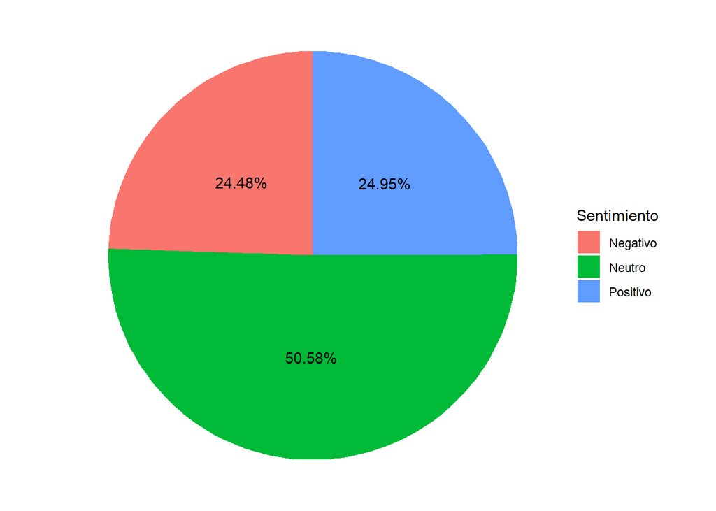

```r
df.sentimet.total <- data.frame(Porcentaje=100*table(sentiment.total)/length(sentiment.total),
                                Sentimiento=c("Negativo","Neutro","Positivo"))

df.sentimet.total <- df.sentimet.total[,c(2,3)]
names(df.sentimet.total) <- c("Porcentaje","Sentimiento")

#pdf(file = "total_clasificaciones.pdf",height = 5, width = 5)

ggplot(df.sentimet.total, aes(x=1, y=Porcentaje, fill=Sentimiento)) +
        geom_bar(stat="identity") +
        geom_text(aes(label = paste0(round(Porcentaje,2),"%")),
                  position = position_stack(vjust = 0.5)) +
        coord_polar(theta = "y")+theme_void()
```

```r
#dev.off()
```

Se realiza el gráfico del número de publicaciones por sentimiento.

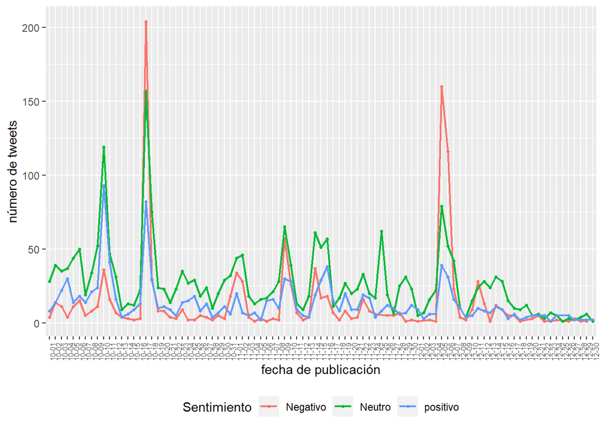

```r
tweets_mes_anyo <- datos.raw %>% mutate(mes_anyo = format(as.Date(date), "%m-%d"))
tweets_mes_anyo$Sentimiento <- ifelse(sentiment.total==-1,"Negativo",
                                    ifelse(sentiment.total==0,"Neutro","positivo"))

#pdf(file = "numero_tweets_publicados_por_sentimiento.pdf",height = 5, width = 10)
tweets_mes_anyo %>% group_by (Sentimiento, mes_anyo) %>% summarise(n = n()) %>%
  ggplot(aes(x = mes_anyo, y = n,colour=Sentimiento)) +
  geom_point(aes(group = Sentimiento),size=0.9) +
  geom_line(aes(group = Sentimiento),size=0.8) +
  labs( x = "fecha de publicación",
       y = "número de tweets") +
  theme(axis.text.x = element_text(angle = 90, size = 6),
        legend.position = "bottom")
```

```r
#dev.off()
```

Se realiza el gráfico de las palabras mas usadas por sentimiento.

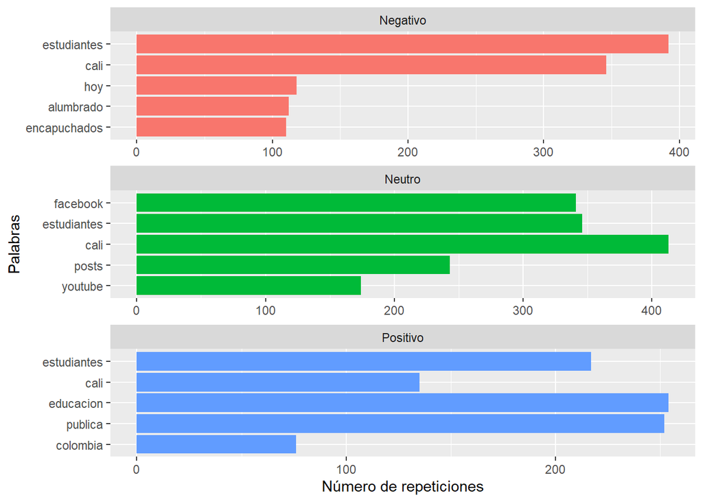

```r
frecuencia.neg <- dfm_select(dfm(x = limpiar(datos.raw[sentiment.total==-1,])),
                                       min_nchar = 3,
                                       max_nchar=15)[,-1]  %>% colSums() %>% sort(decreasing = TRUE)
frecuencia.neg <- data.frame(palabra = names(frecuencia.neg), frec = frecuencia.neg)
frecuencia.neg$Sentimiento <- rep("Negativo",length(frecuencia.neg$palabra))

frecuencia.neu <- dfm_select(dfm(x = limpiar(datos.raw[sentiment.total==0,])),
                                       min_nchar = 3,
                                       max_nchar=15)[,-1]  %>% colSums() %>% sort(decreasing = TRUE)
frecuencia.neu <- data.frame(palabra = names(frecuencia.neu), frec = frecuencia.neu)
frecuencia.neu$Sentimiento <- rep("Neutro",length(frecuencia.neu$palabra))

frecuencia.pos <- dfm_select(dfm(x = limpiar(datos.raw[sentiment.total==1,])),
                                       min_nchar = 3,
                                       max_nchar=15)[,-1]  %>% colSums() %>% sort(decreasing = TRUE)
frecuencia.pos <- data.frame(palabra = names(frecuencia.pos), frec = frecuencia.pos)
frecuencia.pos$Sentimiento <- rep("Positivo",length(frecuencia.pos$palabra))

rm_words <- c("twitter","status","univalle","universidad","valle")

frecuencia <- rbind(frecuencia.neg[! frecuencia.neg$palabra %in% rm_words,][1:5,],
                    frecuencia.neu[! frecuencia.neu$palabra %in% rm_words,][1:5,],
                    frecuencia.pos[! frecuencia.pos$palabra %in% rm_words,][1:5,])


#pdf(file = "palabras_mas_usadas_por_sentimiento.pdf",height = 5, width = 10)
ggplot(frecuencia, aes(x = reorder(palabra,frec), y = frec, fill = Sentimiento)) +
                geom_col() +
                labs(y = "Número de repeticiones", x = "Palabras") +
                theme(legend.position = "none") +
                coord_flip() +
                facet_wrap(~Sentimiento,scales = "free", ncol = 1, drop = TRUE)
```

```r
#dev.off()
```

Se realiza el gráfico de los usuarios con más publicaciones en cada sentimiento.

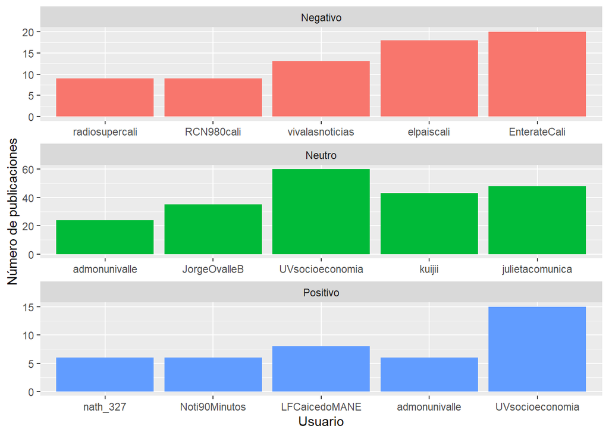

```r
user.neg <- table(datos.raw$username[sentiment.total==-1])
user.neg <- data.frame(user.neg,Sentimiento=rep("Negativo",length(user.neg)))
colnames(user.neg) <- c("Usuario","Frec","Sentimiento")
attach(user.neg)
user.neg <- user.neg[order(-Frec),][1:5,]
detach(user.neg)

user.neu <- table(datos.raw$username[sentiment.total==0])
user.neu <- data.frame(user.neu,Sentimiento=rep("Neutro",length(user.neu)))
colnames(user.neu) <- c("Usuario","Frec","Sentimiento")
attach(user.neu)
user.neu <- user.neu[order(-Frec),][1:5,]
detach(user.neu)

user.pos <- table(datos.raw$username[sentiment.total==1])
user.pos <- data.frame(user.pos,Sentimiento=rep("Positivo",length(user.pos)))
colnames(user.pos) <- c("Usuario","Frec","Sentimiento")
attach(user.pos)
user.pos <- user.pos[order(-Frec),][1:5,]
detach(user.pos)

total.user <- rbind(user.neg,user.neu,user.pos)

#pdf(file = "tweets_usuarios_por_sentimiento.pdf",height = 7, width = 10)
ggplot(total.user, aes(x = reorder(Usuario,Frec), y = Frec, fill = Sentimiento)) +
                geom_col() +
                #theme_bw() +
                labs(y = "Número de publicaciones", x = "Usuario") +
                theme(legend.position = "none") +
                facet_wrap(~Sentimiento,scales = "free", ncol = 1, drop = TRUE)
```

```r
#dev.off()
```